# 36-315 Homework 06, Fall 2016

Your Name Here

Due Wednesday, October 12, 2016 (12pm ET) on Blackboard

## Homework 06: Practice Lab Exam

*General instructions for all assignments*:

- Use this file as the template for your submission. Delete the unnecessary text (e.g. this text, the problem statements, etc). That said, keep the nicely formatted “Problem 1”, “Problem 2”, “a.”, “b.”, etc
- Upload a single `R` Markdown file (named as: [AndrewID]-HW06.Rmd – e.g. “sventura-HW06.Rmd”) to the Homework 06 submission section on Blackboard. You do not need to upload the .html file.
- The instructor and TAs will run your .Rmd file on their computer. **If your .Rmd file does not knit on our computers, you will be automatically be deducted 10 points.**
- Your file should contain the code to answer each question in its own code block. Your code should produce plots/output that will be automatically embedded in the output (.html) file
- Each answer must be supported by written statements (unless otherwise specified)
- Include the name of anyone you collaborated with at the top of the assignment
- Include the style guide you used below under Problem 0

```r
library(data.table)
library(ggplot2)
library(dplyr)
library(gridExtra)
library(devtools)

source_url("https://raw.githubusercontent.com/sventura/315-code-and-datasets/master/code/geom_mosaic.R")

my_theme <-  theme_bw() + # White background, black and white theme
  theme(axis.text = element_text(size = 12, color="indianred4"),
        text = element_text(size = 14, face="bold", color="darkslategrey"))

moma <- fread("https://raw.githubusercontent.com/sventura/315-code-and-datasets/master/data/moma.csv")
```

# Problem 1

(10 points)

**Departmental Favoritism?**

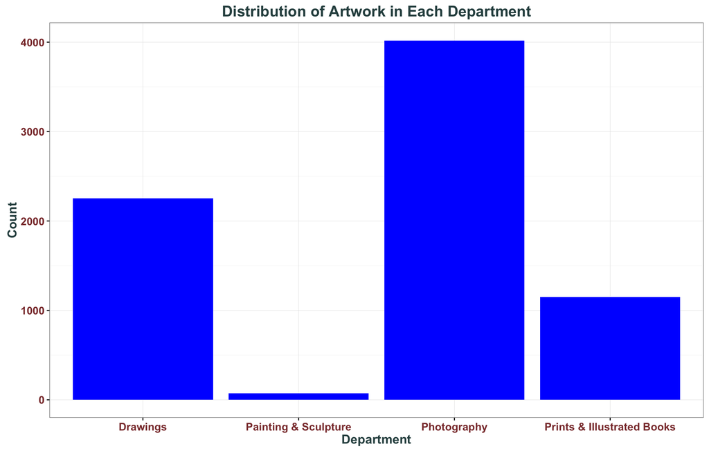

```r
ggplot(data = moma, aes(Department)) +
  geom_bar(fill = "blue") +
  labs(y = "Count") +
  ggtitle("Distribution of Artwork in Each Department") +
  my_theme
```

From the barplot, we see that the `Department` in the MoMA containing the most artwork is Photography and the `Department` containing the least is Painting & Sculpture. Drawing and Prints & Illustrated Books follow behind Photography with 2255 and 1152 pieces of art respectively.

2. As mentioned above, the `Department` with the largest collection of artwork is Photography. Since `Department` is a categorical variable, the distribution cannot have skew.

```r
chisq.test(table(moma$Department), p = c(0.3, 0.01, 0.52, 0.17))
```

```
##
##  Chi-squared test for given probabilities
##
## data:  table(moma$Department)
## X-squared = 15.521, df = 3, p-value = 0.001421
```

**Graphical Choice**

We chose to make a barplot to display the marginal distribution of number of artworks in each department because `Department` is a categorical variable. It is also easier to visually compare category counts in a bar chart than a spine chart.

### Sam Says:

A pie chart would also have been acceptable here, but you would have lost a few points since the problem specifically asked about the number of artworks in each department, not the proportion.

Part (b) was sort of a trick question: categorical variables cannot be skewed. It is also not appropriate to discuss modality with categorical variables, in the sense that the order of the categories is arbitrary unless you are working with an ordered categorical variable (not the case here). If you mentioned that one of the departments had the most artworks and called that category the mode, that’s fine.

Part (c) requires you to run a chi-square test. See the solutions above, and ask questions if you have any confusion. If you drew error bars on the bars and answered the question that way, that’s fine, but it’s not the best way to answer the question, so you wouldn’t have gotten full credit.

# Problem 2

(10 points)

**Curator Bias?**

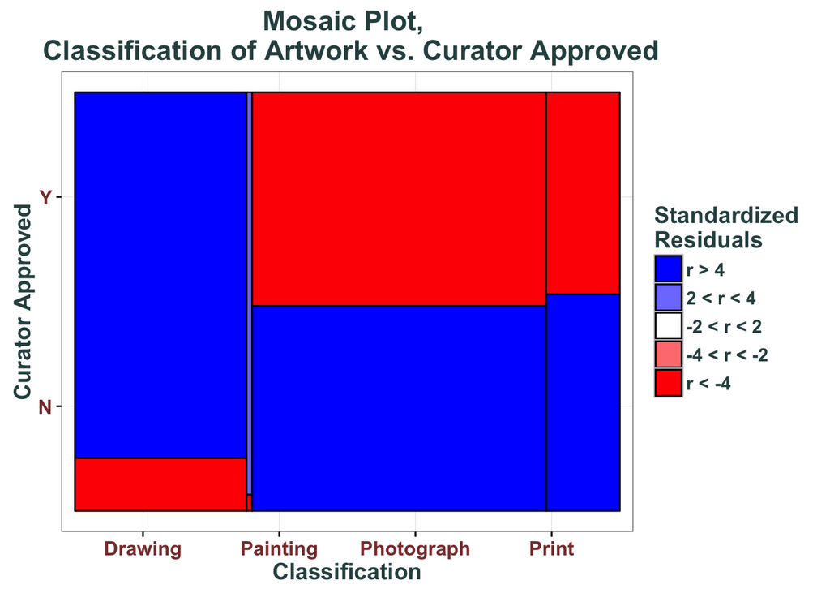

```r
ggplot(data = moma) +
  geom_mosaic(aes(x = Classification, y = CuratorApproved)) +
  mosaic_legend() +
  ggtitle("Mosaic Plot, \n Classification of Artwork vs. Curator Approved") +
  labs(x = "Classification", y = "Curator Approved") +
  my_theme
```

This mosaic plot represents the relationship between classification of Artwork and whether or not it is curator approved. Curator approved is shown on the vertical axis and classification on the horizontal axis.

The shading indicates that whether or not an artwork is curator approved is not independent of its classification. We can see that drawings and paintings are more likely to be approved and photographs and prints are less likely to be approved that what we would expect under independence.

**Graphical Choice**

We made a mosaic plot because of its ability to visualize two categorical variables, while also illustrating the relationship in terms of statistical significance. In addition, the mosaic plot displays all the same information a side-by-side bar chart or stacked bar chart does. The width of the bars in the mosaic plot are proportional to the marginal distribution of classification, while the heights are proportional to the variable CuratorApproved.

### Sam Says:

When you see a question about the association between two categorical variables, you should instantly think of two choices:

- A mosaic plot
- A stacked or side-by-side or facetted bar chart, supplemented with a chi-square test

A mosaic plot provides all of the information you need to answer this problem. That said, using a stacked or side-by-side (or facetted) bar chart, and supplementing your graphic with the results of a statistical test (the chi-square test), is also acceptable. In fact, this option may be preferred if it’s important to include the specific p-value, test statistic, etc.

# Problem 3

(15 points)

**Art Movements**

Characterize the marginal distribution of the year in which the artwork was created (`Date`). Are there any time periods with increases or decreases in the amount of artwork in MoMA? Are there particular types of art that correspond to these increases or decreases? Would it be appropriate to say that the distribution of `Date` is Normal/Gaussian? Why or why not?

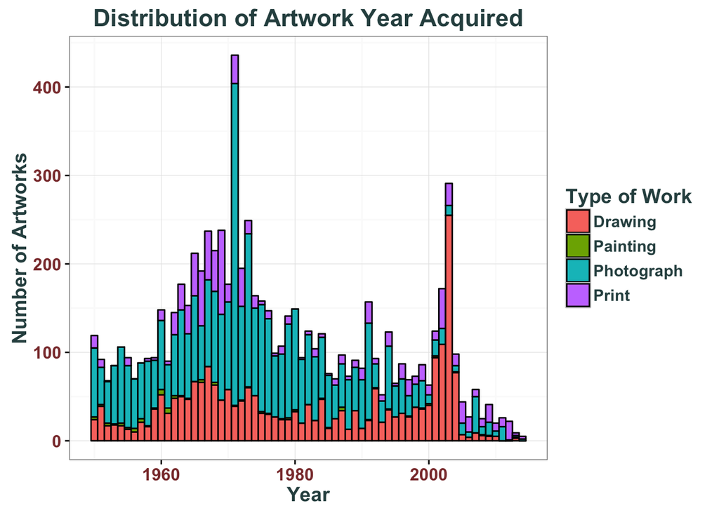

```r
date_bar <- ggplot(data = moma) +
  geom_histogram(aes(x = Date, fill = Classification), color = "black", binwidth = 1) +
  ggtitle("Distribution of Artwork Year Acquired") +
  labs(x = "Year", y = "Number of Artworks", fill = "Type of Work") +
  my_theme
date_bar
```

```r
ks.test(jitter(moma$Date), "pnorm")
```

```
    One-sample Kolmogorov-Smirnov test

data:  jitter(moma$Date)
D = 1, p-value < 2.2e-16
alternative hypothesis: two-sided
```

The years range from 1950 to 2014. The distribution of year of creation seems to be centered at around the early 1970s. There are two modes, a larger one centered around 1970 and another smaller one in the early 2000s. The distribution looks to be skewed right, and it has a fairly wide spread with heavy tails on both sides.

As mentioned when discussing the modes, the early 2000s and the late 1960s to early 1970s seem to have a larger number of works in MoMA compared to other periods. The late 2000s to early 2010s period, as well as the early 1990s, seem to have smaller numbers of works. The 1970s mode has a larger proportion of photographs, while the 2000s mode has a larger proportion of drawings. Prints are more common in the low point of the late 2000s and early 2010s, while there does not seem to be a particular type of classification associated with the early 1990s.

Intuitively, this distribution does not look Gaussian from the graph. Unlike the Gaussian, the distribution of years of artwork creation seems to be bimodal and have relatively heavy tails. The Kolmogorov-Smirnov test confirms this suspicion. According to the results of the K-S test, the probability that we would see the distribution of years that the artworks were created given that the true distribution is Gaussian is near 0. Thus, there is a statistically significant difference between the distribution of year created and the Gaussian.

### Sam Says:

I prefer a histogram here to a density estimate, since the years take integer values, but a density estimate is definitely acceptable here as well.

When characterizing the marginal distribution of continuous variables, mention center, spread, skew/symmetry, modality, shape, and anything else that seems relevant.

When discussing your graphical choices for histograms or density estimates, you should always discuss your choice of bin width, the number of bins, or bandwidth. It’s less important to discuss the specific choice of kernel, since using a Gaussian kernel is appropriate in most cases we see in this class (and in the real world).

**You should NOT have said that this distribution appears to be normally / Gaussian distributed!!!** It breaks basically every rule of normality – it isn’t symmetric, it isn’t unimodal, and it doesn’t have a bell-curve shape. A KS test will confirm this, though it’s definitely not necessary to run a KS test to answer this problem.

# Problem 4

(15 points)

**Monthly Acquisitions**

You are an artist looking to sell a piece to MoMA. (Good luck with that, by the way.) Describe the conditional distributions of the month MoMA acquired the artwork given the department for which it was acquired. Are there particular months in the year when MoMA is more or less likely to acquire new artworks? Does this change depending on the department for which the artwork was acquired? Your friend says that the month of acquisition and the department for which the artwork was acquired are independent. Do you have any evidence to support or deny this claim? Explain.

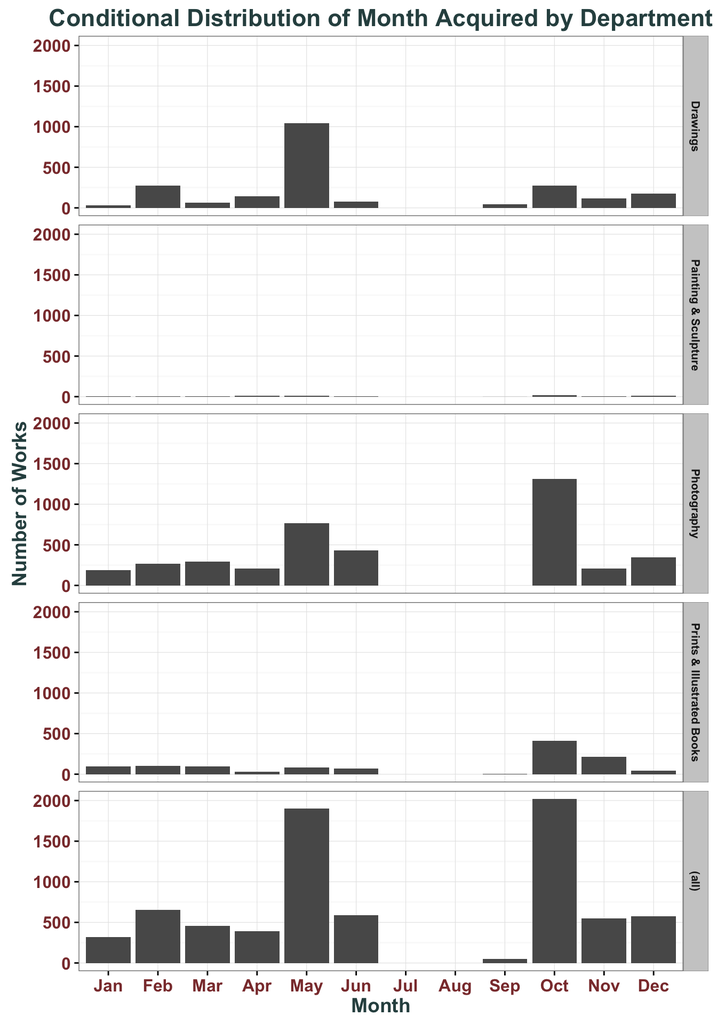

```r
#Characterize month acquired given department
moma$Month_Acquired <- factor(substr(moma$DateAcquired, 6, 7),
                              levels = c("01", "02", "03", "04",
                                         "05", "06", "07", "08",
                                         "09", "10", "11", "12"),
                              labels = c("Jan", "Feb", "Mar", "Apr",
                                         "May", "Jun","Jul", "Aug",
                                         "Sep", "Oct", "Nov", "Dec"))
month_department_bar <- ggplot(data = moma) +
  geom_bar() + aes(x = Month_Acquired) +
  ggtitle("Conditional Distribution of Month Acquired by Department") +
  labs(x = "Month", y = "Number of Works") +
  facet_grid(Department~., margins = TRUE) +
  my_theme +
  scale_x_discrete(drop = FALSE)+
  theme(strip.text.y = element_text(size = 8))
month_department_bar
```

```r
chisq.test(table(moma$Month_Acquired, moma$Department)+0.5)
```

```
    Pearson's Chi-squared test

data:  table(moma$Month_Acquired, moma$Department) + 0.5
X-squared = 1562.5, df = 33, p-value < 2.2e-16
```

Based on the graph, there seems to be strong evidence that the variables are not independent. There definitely seems to be a difference between the proportion of, say, drawings that are acquired in May or October compared to the proportion of photographs. Based on the chi-squared test for independence between the two categorical variables, the month acquired and the department are not independent. We reject the null hypothesis that the categories are independent based on the p-value near 0. *[Note: We need to add 0.5 to every cell because some cells are otherwise empty.]*

### Sam Says:

My preferred graph for this problem is a facetted bar chart of the month variable, with empty spaces for the missing months (use `scale_x_discrete(drop = FALSE)` to do this).

Other accceptable plots: stacked/side-by-side bar charts, mosaic plots. A histogram is not ideal, since the month is an ordered categorical variable. A density estimate is not appropriate.

If you didn’t mention that MoMA is less likely to acquire new artworks in July and August, then you REALLY need to start paying attention to your graphics more! Your graph here should include an empty spot for July and August. If it doesn’t, you will lose points. There are many ways to do this – see the solutions and the various Piazza discussions for more. Ask questions if you do not understand.

A mosaic plot is not necessary to answer the last part of this question. A chi-square test (in addition to the graph you already made for this problem) is sufficient.

# Problem 5

(15 points)

**Untitled**

Find the subset of all artworks with the exact title “Untitled”. How many “Untitled” artworks are there, in total? Does the frequency of “Untitled” artworks change depending on the decade in which the artwork was created?

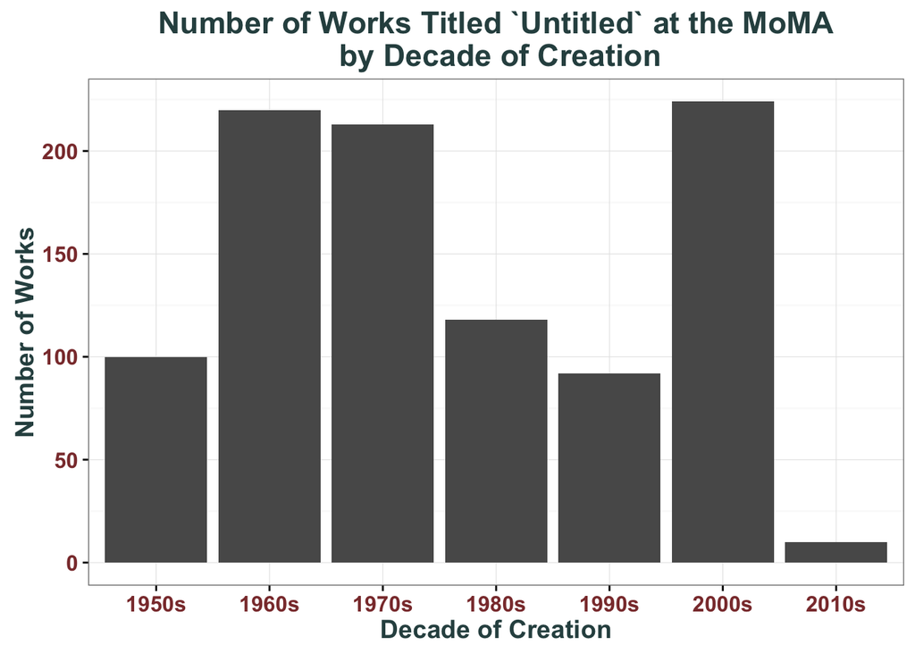

```r
moma <- mutate(moma, decade_num = Date - (Date %% 10),
               Decade = paste0(as.character(decade_num), "s"))
moma_subset <- filter(moma, Title == "Untitled")

ggplot(moma_subset, aes(x = Decade)) + geom_bar() +
    xlab("Decade of Creation") +
    ylab("Number of Works") +
    ggtitle("Number of Works Titled `Untitled` at the MoMA\n by Decade of Creation") +
    my_theme
```

Since we are interested in examining the frequency within each decade we can create an ordered categorical variable for decade and then produce a bar chart to show frequency.

There are 977 works with the Title “Untitled” in the MoMA dataset. We can see that the frequency of “Untitled” works created varies substantially from decade to decade. More works created in the 1960s, 1970s, and 2000s are currently at the MoMA than for any other decade from the 1950s onwards. However, without also examining the total number of works squired in each decade it is impossible to tell if these works become less prevalent relative to the entire population or if it is the case that the number of works the museum acquired has also varied across decade. In particular the fact that the decade in which the fewest number of “Untitled” works then acquired by the MoMA were created should come as no surprise as the decade has not yet ended.

### Sam Says:

If you did something fancy with regular expressions and found all artworks with the word “Untitled”, that’s also acceptable here.

After doing the subsetting, this problem should have been somewhat easy.

# Problem 6

(15 points)

**The Famous Last Words**

Some people believe that artists become more popular after they die. Let’s see if there’s any evidence that this is true.

Create a new variable called `date_delta` (or `date.delta`), which measures the number of years between when the artwork was created (`Date`) and when it was acquired by MoMA (first four characters of `DateAcquired`). Store it in your `moma` `data.frame`.

1. Plot the `Date` vs. the `date_delta`, and describe the distribution you see. Why does there appear to be a certain structure to the joint distribution of these two variables?

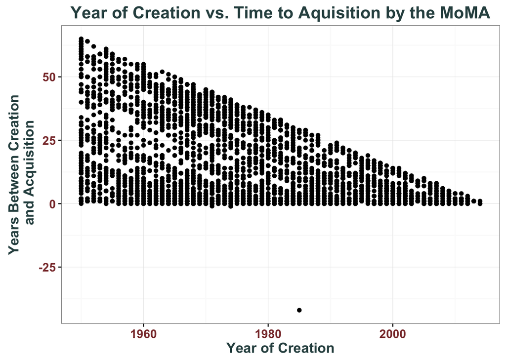

```r
moma <- mutate(moma, YearAcquired = year(as.POSIXct(DateAcquired)),
               date_delta = YearAcquired - Date)

ggplot(moma, aes(x = Date, y = date_delta)) + geom_point() +
    xlab("Year of Creation") +
    ylab("Years Between Creation\n and Acquisition") +
    ggtitle("Year of Creation vs. Time to Aquisition by the MoMA") +
    my_theme
```

```r
outlier_row <- which(moma$date_delta < -1)
```

There appears to be a triangular structure to the data because in general a work cannot be acquired until after it has been created. So the younger a work is the smaller the maximum value of `date_delta`.

2. Are there any potential outliers in this dataset? If so, identify the outliers and characterize them.

We use a scatter plot because we are interested in examining the relationship between two continuous variables. We place `Date` on the x-axis and `date_delta` on the y-axis because `date_delta` is defined as a function of `Date`.

We can see one prominent outlier which appears to show a work acquired long before it was created. This point corresponds to a work titled “War” by Henri Rousseau. While the dataset lists the year of creation as 1985 it also provides a URL[http://www.moma.org/collection/works/73119] with more information. From this we can determine that the work was in fact published in 1985 not created. For completeness we also note that there are 6 works with a listed creation year after the acquisition year. However, in these cases the difference between years is only 1 and likely results from differences in convention in how the field was recorded and do not correspond to true outliers.

### Sam Says:

This problem was a bit challenging, since it requires you to be a statistician / data scientist and thing beyond the dataset that you were presented with.

First, Date Created should go on the x-axis, since it is the independent variable. Date Delta should be on the y-axis, since it “depends” on the Date Created.

The outlier clearly does not make much sense in the context of the problem – how could an artwork be acquired by the museum over 40 years before it was created? There must be some explanation, so you should have sought this explanation out!

The explanation provided above about the outlier is very detailed. If you wrote that the year of creation was a typo after looking up the piece’s title/artist on the internet, that’s fine too.

If you said that the piece could have been commissioned by MoMA, this is a good thought in the sense that you’re thinking about the context of the problem. In fact, several commissioned works do appear in the dataset (Date Acquired = Date Created - 1). However, it’s somewhat unreasonable for a commissioned work to take 40+ years to complete, so you should have sought an alternative explanation.

Finally, the structure in the joint distribution of these two variables is natural. Date Acquired can’t be much more than a year or so before the Date Created (as discussed above), so the Date Delta must have a lower bound of zero (or -1 or -2 or so). Additionally, Date Delta is naturally bounded above by the current year (2016) minus the x-variable (Date Created), since we can’t project what artworks MoMA will buy in the future. You should have thought about this and mentioned these facts.